# Homework 5

Merve Unal - IE582 - Fall 2018 - 2016702108

**1.INTRODUCTION**

**1.1.DATA DESCRIPTION**

From f1 to f162 the features express distances. f163 is the distance of the oxygen atom in the molecule to a designated point in 3-space.This is also called OXY-DIS. f164 is also known as OXY-X, X-displacement from the designated point. f165 is also known as OXY-Y, Y-displacement from the designated point. f166 is also known as OXY-Z, Z-displacement from the designated point.

**1.2.STEPS OF THIS ASSIGNMENT**

**Step 1**

I clustered the instances of this data set given, which is Musk1. I proposed 2 distance measures for computing similarity between the instances, which are euclidean and manhattan. For each measure alternative that i selected, i clustered according to kmeans and hierachical. To work with distances, i used k-medoids approach

**Step 2**

I calculated the distance of its instances to each cluster centroid. Due to the fact that i have 92 cluster centroids, the data matrix i calculated includes 476 rows and 92 columns. Because i have 476 observations and for each observation i calculated the distance to each cluster centroid. I repeated it four times for kmeans-Euclidean,kmeans-Manhattan,hierchical-Euclidean,hierachical-Manhattan.

**Step 3**

**2.FIGURES**

**2.1.STEP 1:CLUSTERING APPROACHES FOR EACH DISTANCE MEASURE ALTERNATIVE**

```
## # A tibble: 6 x 168
##   bagclass bagID    f1    f2    f3    f4    f5    f6    f7    f8    f9
##      <dbl> <dbl> <dbl> <dbl> <dbl> <dbl> <dbl> <dbl> <dbl> <dbl> <dbl>
## 1        1     1    42  -198  -109   -75  -117    11    23   -88   -28
## 2        1     1    42  -191  -142   -65  -117    55    49  -170   -45
## 3        1     1    42  -191  -142   -75  -117    11    49  -161   -45
## 4        1     1    42  -198  -110   -65  -117    55    23   -95   -28
## 5        1     2    42  -198  -102   -75  -117    10    24   -87   -28
## 6        1     2    42  -191  -142   -65  -117    55    49  -170   -45
## # ... with 157 more variables: f10 <dbl>, f11 <dbl>, f12 <dbl>, f13 <dbl>,
## #   f14 <dbl>, f15 <dbl>, f16 <dbl>, f17 <dbl>, f18 <dbl>, f19 <dbl>,
## #   f20 <dbl>, f21 <dbl>, f22 <dbl>, f23 <dbl>, f24 <dbl>, f25 <dbl>,
## #   f26 <dbl>, f27 <dbl>, f28 <dbl>, f29 <dbl>, f30 <dbl>, f31 <dbl>,
## #   f32 <dbl>, f33 <dbl>, f34 <dbl>, f35 <dbl>, f36 <dbl>, f37 <dbl>,
## #   f38 <dbl>, f39 <dbl>, f40 <dbl>, f41 <dbl>, f42 <dbl>, f43 <dbl>,
## #   f44 <dbl>, f45 <dbl>, f46 <dbl>, f47 <dbl>, f48 <dbl>, f49 <dbl>,
## #   f50 <dbl>, f51 <dbl>, f52 <dbl>, f53 <dbl>, f54 <dbl>, f55 <dbl>,
## #   f56 <dbl>, f57 <dbl>, f58 <dbl>, f59 <dbl>, f60 <dbl>, f61 <dbl>,
## #   f62 <dbl>, f63 <dbl>, f64 <dbl>, f65 <dbl>, f66 <dbl>, f67 <dbl>,
## #   f68 <dbl>, f69 <dbl>, f70 <dbl>, f71 <dbl>, f72 <dbl>, f73 <dbl>,
## #   f74 <dbl>, f75 <dbl>, f76 <dbl>, f77 <dbl>, f78 <dbl>, f79 <dbl>,
## #   f80 <dbl>, f81 <dbl>, f82 <dbl>, f83 <dbl>, f84 <dbl>, f85 <dbl>,
## #   f86 <dbl>, f87 <dbl>, f88 <dbl>, f89 <dbl>, f90 <dbl>, f91 <dbl>,
## #   f92 <dbl>, f93 <dbl>, f94 <dbl>, f95 <dbl>, f96 <dbl>, f97 <dbl>,
## #   f98 <dbl>, f99 <dbl>, f100 <dbl>, f101 <dbl>, f102 <dbl>, f103 <dbl>,
## #   f104 <dbl>, f105 <dbl>, f106 <dbl>, f107 <dbl>, f108 <dbl>,
## #   f109 <dbl>, ...
```

```
## [1] 476 168
```

```
## # A tibble: 476 x 1
##    bagclass
##       <dbl>
##  1        2
##  2        2
##  3        2
##  4        2
##  5        2
##  6        2
##  7        2
##  8        2
##  9        2
## 10        2
## # ... with 466 more rows
```

I scaled the data from third column to the last column of musk data. In order to compare the groups that i found with kmeans, i turned the class info from 0 and 1 to 1 and 2 by adding 1 to the first column of Musk data. You can see what i did above.

I proposed 2 distance measures, which are euclidean and manhattan like that i mentioned. You can find the distances done below,respectively.

```
## [1]  9.747368  6.420542  7.203768  6.432229 11.677991  9.191667
```

```
## [1]  80.25242  44.80421  36.51179  25.38245 104.64169  70.14326
```

**CLUSTERING APPROACHES FOR EACH DISTANCE MEASURE ALTERNATIVE**

K means clustering is a clustering algorithm where i attempt to classify my dataset into k number of clusters. Each data is mapped into the cluster with its nearest mean. Therefore, there is no need to find distance for k means. As you see from above, i found euclidean and manhattan distance, respectively. But these will not be used for k means clustering because of the concept of k means clustering. On the other hand, hierchical clustering is a clustering algorithm which mapped into a hierarchy showing similarities and dissimilarities. Therefore, in this clustering algorithm i will use distances that i calculated above which are euclidean distance and manhattan distance.

**- KMEANS APPROACH WITH EUCLIDEAN DISTANCE**

```
## $medoids
##       bagclass bagID          f1           f2         f3          f4
##  [1,]        2     1  0.18072297 -0.881599918 -0.4446318 -1.07134124
##  [2,]        2     2  0.18072297 -0.791013504 -0.9072433 -1.20376358
##  [3,]        2     5  1.72871506  1.020714768  0.2637420 -1.17727911
##  [4,]        2     8  0.23600840 -0.813660108 -1.0373528 -1.26997475
##  [5,]        2    11  0.78886272 -0.870276616 -1.1240924  0.18667099
##  [6,]        2    14  0.73357728  0.001617615  0.7986365 -0.75352762
##  [7,]        2    12 -0.04041876 -0.870276616 -1.0084395  0.19991322
##  [8,]        2    11 -0.20627506  0.080880726  0.8275497 -1.21700581
##  [9,]        2    15  0.23600840  2.300247860  1.2323347 -1.19052134
## [10,]        2    12  0.56772099 -0.553224169 -0.7337640  0.16018652
## [11,]        2    19 -0.04041876 -0.179555213 -0.9650697  1.52413662
## [12,]        2    19  0.67829185 -0.779690203 -0.6325677 -0.32977614
## [13,]        2    16 -0.04041876  0.114850632  0.8275497 -0.78001209
```

[output cut: 3289 more lines]

```
##
##       1  2  3  4  5  6  7  8  9 10 11 12 13 14 15 16 17 18 19 20 21 22 23
##   1   3  1  0  2  0  0  0  0  0  0  0  0  0  0  0  0  0  0  0  0  0  0  0
##   2   1  3  2  1  3  2  0  0  0  0  0  0  0  0  0  0  0  0  0  0  0  0  0
##   3   0  0  0  0  1  0  0  0  0  0  0  0  0  0  0  0  0  0  0  0  0  0  0
##   4   0  0  0  0  0  0  2  2  0  0  0  0  0  0  0  0  0  0  0  0  0  0  0
##   5   0  0  0  0  0  0  0  0  2  3  2  0  0  0  0  0  0  0  0  0  0  0  0
##   6   0  0  0  0  0  0  0  0  1  0  0  1  0  1  1  0  0  1  2  0  0  0  0
##   7   0  0  0  0  0  0  0  0  1  0  0  2  0  0  0  0  0  0  0  0  0  0  0
##   8   0  0  0  0  0  0  0  0  1  3  3  1  0  0  0  0  0  0  0  0  0  0  0
##   9   0  0  0  0  0  0  0  0  0  0  0  1  2  0  1  0  0  1  1  0  0  0  0
##   10  0  0  0  0  0  0  0  0  0  0  0  3  0  0  0  0  0  0  0  0  0  0  0
##   11  0  0  0  0  0  0  0  0  0  0  0  0  2  0  1  0  0  1  2  0  0  0  0
##   12  0  0  0  0  0  0  0  0  0  0  0  0  0  1  0  0  0  1  2  0  0  0  0
##   13  0  0  0  0  0  0  0  0  0  0  0  0  0  0  1  2  3  0  1  0  0  0  0
```

[output cut: 361 more lines]

As you see i clustered as 92 groups.

**- KMEANS APPROACH WITH MANHATTAN DISTANCE**

```
## $medoids
##       bagclass bagID          f1           f2          f3          f4
##  [1,]        2     1  0.18072297 -0.881599918 -0.44463182 -1.07134124
##  [2,]        2     2  0.18072297 -0.791013504 -0.90724328 -1.20376358
##  [3,]        2     3  0.29129383 -0.439991152  0.23482877 -1.19052134
##  [4,]        2     6  0.45715013  0.205437045  0.27819859 -1.70696847
##  [5,]        2    35  0.23600840 -0.892923220 -1.09517918 -0.46219848
##  [6,]        2    12  0.56772099 -0.553224169 -0.73376398  0.16018652
##  [7,]        2     9 -0.04041876 -0.587194074 -1.13854901  0.19991322
##  [8,]        2    14  0.73357728  0.001617615  0.79863649 -0.75352762
##  [9,]        2    18  0.23600840  0.171467140  0.84200631 -0.93891890
## [10,]        2    16 -0.04041876  0.114850632  0.82754971 -0.78001209
## [11,]        2    10  0.78886272 -0.870276616 -0.97952632  0.18667099
## [12,]        2    19 -0.04041876 -0.179555213 -0.96506971  1.52413662
## [13,]        2    15  0.23600840  2.300247860  1.23233474 -1.19052134
```

[output cut: 3289 more lines]

```
##
##      1 2 3 4 5 6 7 8 9 10 11 12 13 14 15 16 17 18 19 20 21 22 23 24 25 26
##   1  3 1 0 2 0 0 0 0 0  0  0  0  0  0  0  0  0  0  0  0  0  0  0  0  0  0
##   2  1 3 1 0 2 1 1 1 0  0  0  0  0  0  0  0  0  0  0  0  0  0  0  0  0  0
##   3  0 0 1 0 2 0 0 0 0  0  0  0  0  0  0  0  0  0  0  0  0  0  0  0  0  0
##   4  0 0 0 1 0 1 1 0 0  0  0  0  0  0  0  0  0  0  0  0  0  0  0  0  0  0
##   5  0 0 0 0 0 0 0 1 0  0  0  0  0  0  0  0  0  0  0  0  0  0  0  0  0  0
##   6  0 0 0 0 0 0 0 0 1  0  0  2  0  0  0  0  0  0  0  0  0  0  0  0  0  0
##   7  0 0 0 0 0 0 0 0 2  0  0  3  1  0  0  0  0  0  0  0  0  0  0  0  0  0
##   8  0 0 0 0 0 0 0 0 1  0  0  1  0  1  0  0  0  1  1  0  0  0  0  0  0  0
##   9  0 0 0 0 0 0 0 0 1  0  0  2  0  0  0  0  0  1  0  0  0  0  0  0  0  0
##   10 0 0 0 0 0 0 0 0 0  3  3  0  0  0  1  2  2  0  0  0  0  0  0  0  0  0
##   11 0 0 0 0 0 0 0 0 0  3  2  0  0  0  0  0  0  0  0  0  0  0  0  0  0  0
##   12 0 0 0 0 0 0 0 0 0  0  0  0  1  0  1  0  0  1  2  0  0  0  0  0  0  0
##   13 0 0 0 0 0 0 0 0 0  0  0  0  2  0  1  0  1  0  1  0  0  0  0  0  0  0
```

[output cut: 361 more lines]

As you see i clustered as 92 groups.

**- HIERACHICAL APPROACH WITH EUCLIDEAN DISTANCE**

```
## $merge
##        [,1] [,2]
##   [1,] -228 -232
##   [2,] -214 -215
##   [3,] -227 -231
##   [4,]  -61  -65
##   [5,] -189 -191
##   [6,] -245 -249
##   [7,] -391 -405
##   [8,] -177 -178
##   [9,] -202 -205
##  [10,]  -72  -74
##  [11,]  -70  -76
##  [12,] -185 -192
##  [13,] -304 -305
```

[output cut: 598 more lines]

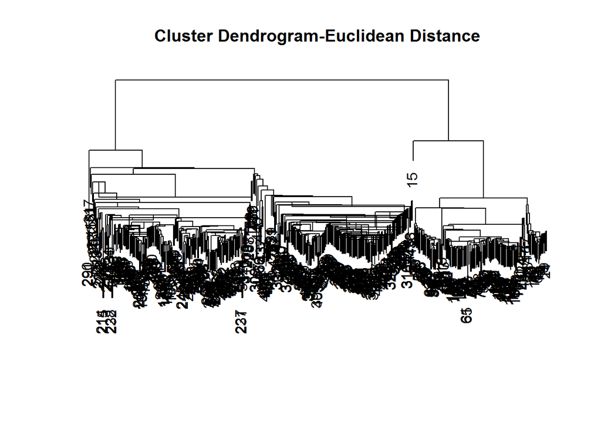

```
## [1] 1 1 1 1 1 1
```

```
##
## clusterCut_musk_euc  1  2  3  4  5  6  7  8  9 10 11 12 13 14 15 16 17 18
##                  1   4  4  2  3  1  2  2  2  0  0  0  0  0  0  0  0  0  0
##                  2   0  0  0  0  1  0  0  0  0  0  0  0  0  0  0  0  0  0
##                  3   0  0  0  0  1  0  0  0  0  0  0  0  0  0  0  0  0  0
##                  4   0  0  0  0  1  0  0  0  0  0  0  0  0  0  0  0  0  0
##                  5   0  0  0  0  0  0  0  0  1  0  0  2  0  0  0  0  0  0
##                  6   0  0  0  0  0  0  0  0  2  3  2  0  2  1  1  1  2  2
##                  7   0  0  0  0  0  0  0  0  2  3  3  3  2  1  3  2  3  2
##                  8   0  0  0  0  0  0  0  0  0  0  0  2  0  0  0  0  0  0
##                  9   0  0  0  0  0  0  0  0  0  0  0  1  0  0  0  0  0  0
##                  10  0  0  0  0  0  0  0  0  0  0  0  0  0  0  0  0  0  0
##                  11  0  0  0  0  0  0  0  0  0  0  0  0  0  0  0  0  0  0
##                  12  0  0  0  0  0  0  0  0  0  0  0  0  0  0  0  0  0  0
##                  13  0  0  0  0  0  0  0  0  0  0  0  0  0  0  0  0  0  0
```

[output cut: 549 more lines]

As you see i clustered as 92 groups.

**- HIERACHICAL APPROACH WITH MANHATTAN DISTANCE**

```
## $merge
##        [,1] [,2]
##   [1,] -228 -232
##   [2,] -227 -231
##   [3,] -214 -215
##   [4,]  -61  -65
##   [5,] -108 -120
##   [6,] -129 -137
##   [7,] -124 -132
##   [8,] -292 -297
##   [9,] -125 -133
##  [10,]  -10  -16
##  [11,]  -36  -38
##  [12,] -391 -405
##  [13,]  -58  -63
```

[output cut: 598 more lines]

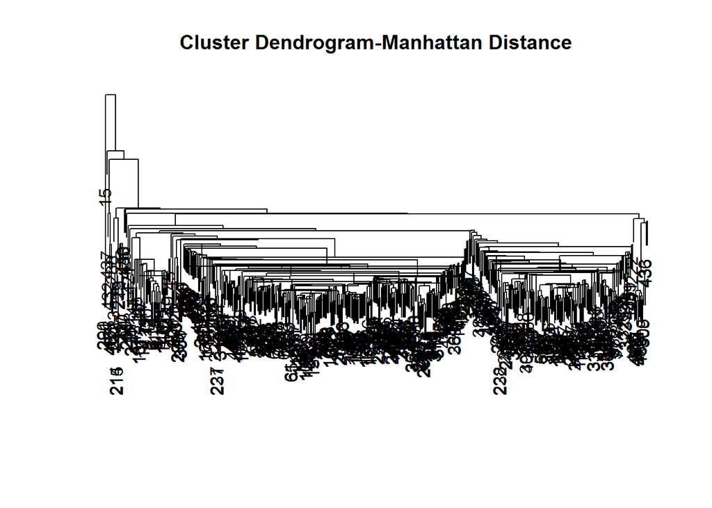

```
## [1] 1 1 1 1 1 1
```

```
##
## clusterCut_musk_man  1  2  3  4  5  6  7  8  9 10 11 12 13 14 15 16 17 18
##                  1   4  4  2  3  3  2  2  2  0  0  0  0  0  0  0  0  0  0
##                  2   0  0  0  0  1  0  0  0  0  0  0  0  0  0  0  0  0  0
##                  3   0  0  0  0  0  0  0  0  3  3  2  2  2  1  1  1  2  2
##                  4   0  0  0  0  0  0  0  0  2  3  3  1  2  1  3  2  3  2
##                  5   0  0  0  0  0  0  0  0  0  0  0  2  0  0  0  0  0  0
##                  6   0  0  0  0  0  0  0  0  0  0  0  1  0  0  0  0  0  0
##                  7   0  0  0  0  0  0  0  0  0  0  0  1  0  0  0  0  0  0
##                  8   0  0  0  0  0  0  0  0  0  0  0  1  0  0  0  0  0  0
##                  9   0  0  0  0  0  0  0  0  0  0  0  0  0  0  0  0  0  0
##                  10  0  0  0  0  0  0  0  0  0  0  0  0  0  0  0  0  0  0
##                  11  0  0  0  0  0  0  0  0  0  0  0  0  0  0  0  0  0  0
##                  12  0  0  0  0  0  0  0  0  0  0  0  0  0  0  0  0  0  0
##                  13  0  0  0  0  0  0  0  0  0  0  0  0  0  0  0  0  0  0
```

[output cut: 549 more lines]

As you see i clustered as 92 groups.

**2.2.STEP 2:CALCULATE THE DISTANCE OF ITS INSTANCES TO EACH CLUSTER CENTROID**

**- KMEANS APPROACH WITH EUCLIDEAN DISTANCE**

```
##      bagclass bagID       f1         f2         f3        f4         f5
## [1,]        2     1 0.180723 -0.8815999 -0.4301752 -1.203764 -0.1637934
## [2,]        2     1 0.180723 -0.8023368 -0.9072433 -1.071341 -0.1637934
## [3,]        2     1 0.180723 -0.8023368 -0.9072433 -1.203764 -0.1637934
## [4,]        2     1 0.180723 -0.8815999 -0.4446318 -1.071341 -0.1637934
## [5,]        2     2 0.180723 -0.8815999 -0.3289789 -1.203764 -0.1637934
## [6,]        2     2 0.180723 -0.8023368 -0.9072433 -1.071341 -0.1637934
##             f6        f7        f8        f9       f10       f11
## [1,] 0.2255951 0.3718827 -1.263585 0.6545626 0.6772360 -1.534785
## [2,] 0.7037235 0.6158746 -2.345572 0.4780699 1.1188121 -2.571670
## [3,] 0.2255951 0.6158746 -2.226817 0.4780699 0.6634368 -2.047653
## [4,] 0.7037235 0.3718827 -1.355949 0.6545626 1.1188121 -2.304087
## [5,] 0.2147286 0.3812670 -1.250390 0.6545626 0.6634368 -1.545935
## [6,] 0.7037235 0.6158746 -2.345572 0.4780699 1.1326113 -2.560521
##             f12         f13       f14       f15        f16        f17
```

[output cut: 181 more lines]

```
## [1] 476  92
```

```
##          [,1]      [,2]     [,3]     [,4]     [,5]     [,6]     [,7]
## [1,] 7.203768  9.191667 20.43836 14.03748 18.92448 23.18338 22.53809
## [2,] 6.344397  9.739859 22.00190 12.77645 19.01994 22.87868 22.25942
## [3,] 9.361300  6.549678 20.79455 12.88467 18.72234 23.24223 22.12765
## [4,] 0.000000 11.458675 21.58899 13.95019 19.28888 22.84961 22.73027
## [5,] 9.660312  6.498023 19.56243 11.99027 19.38075 21.76726 21.02390
## [6,] 9.054756  7.200070 21.20288 10.46594 19.45101 21.44971 20.68280
##          [,8]     [,9]    [,10]    [,11]    [,12]    [,13]    [,14]
## [1,] 20.43095 24.80649 22.33899 27.50724 26.82290 22.82797 21.91038
## [2,] 20.44364 24.42460 21.79298 26.75097 26.18470 22.59681 22.00986
## [3,] 20.58261 24.75279 21.60837 26.56962 25.91053 22.92299 21.45866
## [4,] 20.33550 24.52106 22.58748 27.76920 27.17583 22.54223 22.52175
## [5,] 20.47480 23.72171 21.33915 26.03995 25.84396 22.65060 22.03411
## [6,] 20.50366 23.31241 20.75457 25.20788 25.16792 22.42257 22.12530
##         [,15]    [,16]    [,17]    [,18]    [,19]    [,20]    [,21]
```

[output cut: 83 more lines]

As you see from above, for each bag i calculated the distance between instances and each centroid. I did it by using k means approach and the distance measure for this case is euclidean.

**- KMEANS APPROACH WITH MANHATTAN DISTANCE**

```
## [1] 476  92
```

```
##          [,1]     [,2]      [,3]      [,4]      [,5]     [,6]     [,7]
## [1,] 36.51179 70.14326  75.63597  95.93631 144.16556 219.8060 195.3661
## [2,] 44.72466 61.75329 118.91101 128.32161 113.97995 210.7985 183.3625
## [3,] 74.33123 26.02425  86.43771 107.43441 135.36445 209.0871 180.2301
## [4,]  0.00000 99.47165 105.48757 113.77242 122.26092 223.1340 200.2196
## [5,] 61.10242 47.61392  67.60746  79.35216 122.73882 210.7060 177.4058
## [6,] 69.36910 37.89867 111.26168 112.03063  91.40827 201.4032 164.4194
##          [,8]     [,9]    [,10]    [,11]    [,12]    [,13]    [,14]
## [1,] 215.0160 212.1641 183.5465 154.8668 224.6825 228.1772 200.4125
## [2,] 203.3884 198.9529 171.6592 148.9305 206.2387 217.9134 189.6152
## [3,] 215.1367 209.3265 183.4244 147.0177 204.7152 230.1632 184.6490
## [4,] 204.7482 203.5596 173.6136 158.3556 227.7394 217.6161 207.1511
## [5,] 201.4649 208.5878 193.9792 172.7988 207.5300 220.5356 191.8569
## [6,] 189.7733 195.2287 181.7826 166.5975 187.8727 210.3090 180.9160
##         [,15]    [,16]    [,17]    [,18]    [,19]    [,20]    [,21]
```

[output cut: 83 more lines]

As you see from above, for each bag i calculated the distance between instances and each centroid. I did it by using k means approach and the distance measure for this case is manhattan.

**- HIERCHICAL APPROACH WITH EUCLIDEAN DISTANCE**

```
## [1] 476  92
```

```
##          [,1]     [,2]     [,3]     [,4]     [,5]     [,6]     [,7]
## [1,] 24.53457 864.2284 18.83628 19.29703 20.37074 18.48939 28.23346
## [2,] 23.56605 876.7833 20.42695 19.58138 20.17225 18.02290 32.62398
## [3,] 24.14622 886.0954 20.66079 19.49804 19.41478 16.51111 33.25094
## [4,] 24.23017 903.3440 20.69762 19.36272 21.15993 19.01794 32.19564
## [5,] 22.41096 915.3886 19.22982 19.82680 20.23943 19.04003 30.89242
## [6,] 21.84093 913.7636 20.14872 18.86483 19.48168 19.65041 28.58625
##          [,8]     [,9]    [,10]    [,11]    [,12]    [,13]    [,14]
## [1,] 18.30538 17.77740 21.05636 17.97951 23.03403 21.75331 19.49831
## [2,] 19.73772 18.57628 21.00895 18.42854 20.65230 20.24418 19.63429
## [3,] 17.06309 18.14431 20.78182 18.25107 21.71354 20.98139 18.68219
## [4,] 19.87817 18.22714 22.67739 19.50937 21.75307 21.92167 21.39451
## [5,] 18.23674 19.26669 20.73074 18.89264 19.66815 20.16909 18.63681
## [6,] 19.65159 18.64760 20.84264 19.54440 21.26912 20.29325 19.64365
##         [,15]    [,16]    [,17]    [,18]    [,19]    [,20]    [,21]
```

[output cut: 83 more lines]

As you see from above, for each bag i calculated the distance between instances and each centroid. I did it by using hierachical approach and the distance measure for this case is euclidean.

**- HIERCHICAL APPROACH WITH MANHATTAN DISTANCE**

```
## [1] 476  92
```

```
##          [,1]     [,2]     [,3]     [,4]     [,5]     [,6]     [,7]
## [1,] 78.37919 119.0885 216.3183 246.4670 224.7933 219.7454 213.8259
## [2,] 75.24412 164.2763 202.7808 237.1274 220.7163 221.5105 210.1938
## [3,] 70.63118 131.1163 200.9839 246.6846 218.5406 218.8341 206.7261
## [4,] 79.77319 149.9031 219.8653 238.5606 228.4853 224.0225 219.0079
## [5,] 65.90704 110.0400 213.6673 239.6120 206.3639 216.4004 195.4984
## [6,] 62.62449 155.5796 199.7378 230.0822 201.8655 218.2048 191.5109
##          [,8]     [,9]    [,10]    [,11]    [,12]    [,13]    [,14]
## [1,] 230.3282 231.7832 210.9304 219.1083 206.9642 205.3074 207.0305
## [2,] 240.4316 220.6260 211.6413 225.4241 198.8185 209.4913 212.2541
## [3,] 229.8919 231.9656 202.1564 220.3327 195.2990 207.9649 205.9227
## [4,] 242.5214 222.0695 222.2582 226.0446 212.0568 208.4515 215.0159
## [5,] 216.9258 216.8408 203.5832 211.8870 198.1609 196.1418 223.0674
## [6,] 227.0373 205.7736 204.4253 218.1019 190.2714 200.5918 228.3696
##         [,15]    [,16]    [,17]     [,18]     [,19]     [,20]     [,21]
```

[output cut: 83 more lines]

As you see from above, for each bag i calculated the distance between instances and each centroid. I did it by using hierchical approach and the distance measure for this case is manhattan.

**KMEANS-EUCLIDEAN**

```
##   Group.1        V1       V2       V3        V4        V5        V6
## 1       1  5.961124 10.45550 20.96869 13.331700 19.173240 22.351288
## 2       2 12.419044  8.72392 20.20583 13.059569 19.991637 21.890303
## 3       3 21.588987 19.89226  0.00000 22.027368 26.960830 25.152664
## 4       4 13.517351 11.04028 21.19570  6.084745 15.011120 16.433114
## 5       5 19.504806 18.79478 26.48124 13.952384  6.347278 18.979229
## 6       6 24.985326 23.56422 26.07017 18.602865 20.956428  7.442716
##         V7       V8       V9      V10      V11      V12      V13      V14
## 1 22.09294 20.09239 23.84603 22.03312 26.77510 26.26206 22.16578 21.79402
## 2 21.60330 20.88808 23.06854 21.50471 25.51400 25.27048 22.66279 21.85205
## 3 27.19603 26.35025 26.86955 27.71557 30.07100 30.83539 27.76045 27.68297
## 4 16.53218 16.21369 18.70155 16.82079 19.77067 19.76872 17.33316 16.93204
## 5 12.35215 18.08203 20.57881 11.61070 14.95395 14.37956 18.19088 11.27358
## 6 21.62234 12.63361 12.05466 23.56680 20.54898 21.23448 11.64423 19.93054
##        V15      V16      V17      V18      V19      V20      V21      V22
```

[output cut: 69 more lines]

**KMEANS-MANHATTAN**

```
##   Group.1        V1        V2        V3        V4        V5        V6
## 1       1  34.80093  85.84795  93.22987 108.79150 128.67145 220.10195
## 2       2 102.58693  54.21186 102.66114 110.04585 122.91234 196.52806
## 3       3 126.18819  98.87568  33.70390  95.11872 181.37885 245.94200
## 4       4 101.39702  90.37992  86.42170  34.39302 144.66308 222.33356
## 5       5 131.20805  99.35756 149.01684 144.83086  49.51804 198.87505
## 6       6 213.99346 190.07962 214.36465 223.94618 198.89216  30.49066
##         V7       V8       V9      V10       V11      V12      V13
## 1 193.9049 205.9665 204.1630 178.7908 160.78117 220.2651 219.3383
## 2 163.7978 202.3654 205.7772 196.0118 159.35553 187.7643 218.2994
## 3 224.7590 213.6579 204.6906 215.7209 214.93602 242.8548 213.0763
## 4 179.4336 170.7685 199.1909 177.3211 181.15161 200.4100 206.6741
## 5 161.3381 181.3924 182.2347 171.3492 159.63504 178.6886 199.0493
## 6  83.4761 229.4955 211.2834 221.2259  88.04958 114.7996 229.6316
##         V14      V15      V16      V17      V18      V19      V20      V21
```

[output cut: 69 more lines]

**OPTIMAL K VALUE**

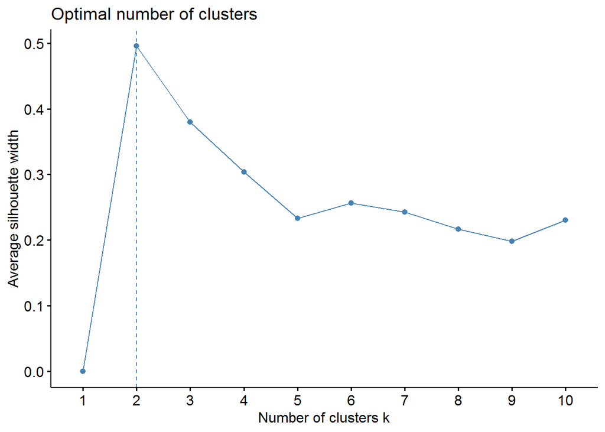

```r
fviz_nbclust_silh<-fviz_nbclust(musk, kmeans, method = "silhouette") # finds optimal number of clusters
plot(fviz_nbclust_silh)
```

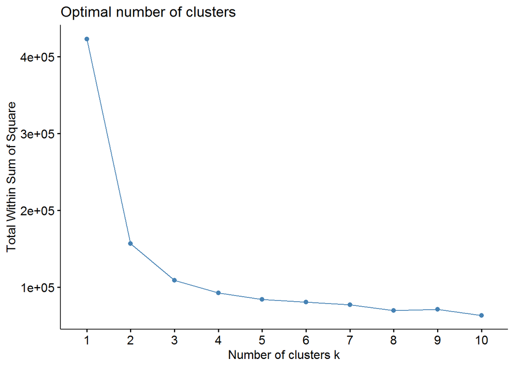

```r
fviz_nbclust_wss<-fviz_nbclust(musk, kmeans, method = "wss") # finds optimal number of clusters
plot(fviz_nbclust_wss)
```

You can see 2 plots above. The first plot represents average silhoutte width versus number of clusters. As you see optimum number is determined as 2. Actually, accoridng to some reserach and articles done, the optimum number of k is generally 2 when you want to observe this performance measure, which is average silhoutte width. It is actually the disadvantage of this performance criteria. As an example of it, optimum number of cluster is 2 for Musk1 data as you see, which accepts and shows the accuracy of this academic research. The second plot shows total SSE and number of clusters. As you see, as the number of clusters increases, total sse decreases.

Transform instance level representation to bag level representation

**CODES**

**STEP1**

require(readxl)

require(utils)

require(dplyr)

require(caret)

require(stats)

require(milr)

require(magrittr)

require(reshape2)

require(data.table)

require(factoextra)

require(cluster)

require(gplots)

musk<-read_excel(“C:/Users/Merve/Desktop/Hmw5.xls”)

head(musk)

dim(musk)

musk[,3:ncol(musk)] <- scale(musk[,3:ncol(musk)])

musk[,1]<-musk[,1]+1 #kmeans ile bulduğum grupları karşılaştırmak adına

musk[,1]

musk<- na.omit(musk)

# Split the data into training and test set

set.seed(135)

euclidean_musk<-dist(musk,method=“euclidean”)

head(euclidean_musk)

manhattan_musk<-dist(musk,method=“manhattan”)

head(manhattan_musk)

training_samples_musk <- musk$bagclass %>% createDataPartition(p = 0.7, list = FALSE)

training_musk <-musk[training_samples_musk, ]

test_musk <-musk[-training_samples_musk, ]

#KMEANS-EUCLIDEAN

kmeans_musk_euc<-pam(musk, 92, metric = “euclidean”, stand = FALSE)

head(kmeans_musk_euc)

table(kmeans_musk_euc$cluster,musk$bagID)

#KMEANS-MANHATTAN

kmeans_musk_man<-pam(musk, 92, metric = “manhattan”, stand = FALSE)

head(kmeans_musk_man)

table(kmeans_musk_man$cluster,musk$bagID)

#HIERCHICAL-EUCLIDEAN

hclust_musk_euc = hclust(euclidean_musk, method=“centroid”)

head(hclust_musk_euc)

plot(hclust_musk_euc, axes=F,xlab=’‘, ylab=’‘,sub =’‘, main=’Cluster Dendrogram-Euclidean Distance’)

clusterCut_musk_euc <- cutree(hclust_musk_euc, 92) #92 sınıfa ayrıldı

head(clusterCut_musk_euc)

table(clusterCut_musk_euc,musk$bagID)

#HIERCHICAL-MANHATTAN

hclust_musk_man = hclust(manhattan_musk, method=“centroid”)

head(hclust_musk_man)

plot(hclust_musk_man, axes=F,xlab=’‘, ylab=’‘,sub =’‘, main=’Cluster Dendrogram-Manhattan Distance’)

clusterCut_musk_man <- cutree(hclust_musk_man, 92) #92 sınıfa ayrıldı

head(clusterCut_musk_man)

table(clusterCut_musk_man,musk$bagID)

**STEP2**

#KMEANS APPROACH WITH EUCLIDEAN DISTANCE

kmeans_musk_euc_medoids<-kmeans_musk_euc$medoids

head(kmeans_musk_euc$data)

distanceMatrix_euc_kmeans <- matrix(NA, nrow=dim(musk)[1], ncol=dim(kmeans_musk_euc$medoids)[1])

```
for(i in 1:nrow(kmeans_musk_euc$medoids)) {
    distanceMatrix_euc_kmeans[,i] <- sqrt(rowSums(t(t(musk)-kmeans_musk_euc$medoids[i,])^2))
}
```

dim(distanceMatrix_euc_kmeans)

head(distanceMatrix_euc_kmeans)

#KMEANS APPROACH WITH MANHATTAN DISTANCE

kmeans_musk_man_medoids<-kmeans_musk_man$medoids

distanceMatrix_man_kmeans <- matrix(NA, nrow=dim(musk)[1], ncol=dim(kmeans_musk_man_medoids)[1])

```
for(i in 1:nrow(kmeans_musk_man_medoids)) {
    distanceMatrix_man_kmeans[,i] <- rowSums(abs(t(t(musk)-kmeans_musk_man_medoids[i,])))

}
```

dim(distanceMatrix_man_kmeans)

head(distanceMatrix_man_kmeans)

#HIERCHICAL APPROACH WITH EUCLIDEAN DISTANCE

clusterCut_musk_euc <- cutree(hclust_musk_euc, 92)

cluster_centroid_euc = function(i,musk,clusterCut_musk_euc) { ind=(clusterCut_musk_euc==i) colMeans(musk[ind,]) }

centroid_euc_hier<-sapply(unique(clusterCut_musk_euc),cluster_centroid_euc,musk,clusterCut_musk_euc)

distanceMatrix_euc_hierach <- matrix(NA, nrow=dim(musk)[1], ncol=dim(centroid_euc_hier)[2])

for(i in 1:ncol(centroid_euc_hier)) { distanceMatrix_euc_hierach[,i] <- sqrt(rowSums(t(t(musk)-centroid_euc_hier[i,])^2)) }

dim(distanceMatrix_euc_hierach)

head(distanceMatrix_euc_hierach)

#HIERCHICAL APPROACH WITH MANHATTAN DISTANCE

clusterCut_musk_man <- cutree(hclust_musk_man, 92) #92 sınıfa ayrıldı

cluster_centroid_man = function(i,musk,clusterCut_musk_man) { ind=(clusterCut_musk_man==i) colMeans(musk[ind,]) }

centroid_man_hier<-sapply(unique(clusterCut_musk_man),cluster_centroid_man,musk,clusterCut_musk_man)

distanceMatrix_man_hierach <- matrix(NA, nrow=dim(musk)[1], ncol=dim(centroid_man_hier)[2])

```
for(i in 1:ncol(centroid_man_hier)) {
    distanceMatrix_man_hierach[,i] <- rowSums(abs(t(t(musk)-centroid_man_hier[,i])))
}
```

dim(distanceMatrix_man_hierach)

head(distanceMatrix_man_hierach)

**STEP3**

#KMEANS-EUCLIDEAN

aggregate_kmeans_euc<-aggregate(distanceMatrix_euc_kmeans, list(kmeans_musk_euc$clustering), mean)

head(aggregate_kmeans_euc)

#KMEANS-MANHATTAN

aggregate_kmeans_man<-aggregate(distanceMatrix_man_kmeans, list(kmeans_musk_man$clustering), mean)

head(aggregate_kmeans_man)

#OPTIMAL K VALUE

fviz_nbclust_silh<-fviz_nbclust(musk, kmeans, method = “silhouette”) # finds optimal number of clusters

plot(fviz_nbclust_silh)

fviz_nbclust_wss<-fviz_nbclust(musk, kmeans, method = “wss”) # finds optimal number of clusters

plot(fviz_nbclust_wss)